# York Street Footfall Analysis for Optimal Vendor Positioning

## Check the discrete and categorical data

```r
count(york_footfall, LocationName) #Although some locations contain less data, it don't seem to have any error such as wrong typing etc.
```

```
## # A tibble: 6 × 2
##   LocationName                 n
##   <chr>                    <int>
## 1 Church Street              900
## 2 Coney Street              1826
## 3 Micklegate                1826
## 4 Parliament Street         1668
## 5 Parliament Street at M&S   158
## 6 Stonegate                 1826
```

```r
count(york_footfall, WeekDay) #According to the result, the weekday data don't present any errors because there is no weird index other than weekdays.
```

```
## # A tibble: 7 × 2
##   WeekDay       n
##   <chr>     <int>
## 1 Friday     1173
## 2 Monday     1172
## 3 Saturday   1173
## 4 Sunday     1173
## 5 Thursday   1173
## 6 Tuesday    1172
## 7 Wednesday  1168
```

```r
# Based on these examinations, there are no potential errors in these columns.
```

## Data Cleaning

Firstly, records for missing values in the columns of TotalCount from the york_footfall data will be removed. Data with a TotalCount value larger than 100,000 will also be excluded since they are abnormal and could affect the following analysis

```r
# Filter the missing data and outliers out to ensure this data's integrity and quality.
york_footfall <- york_footfall %>%
  filter(!is.na(TotalCount)) %>%
  filter(TotalCount < 100000)

head(york_footfall)
```

```
## # A tibble: 6 × 6
##   Date       SiteName LocationName             WeekDay  TotalCount Recording_ID
##   <date>     <chr>    <chr>                    <chr>         <dbl>        <dbl>
## 1 2015-01-01 York     Church Street            Thursday       1952       375836
## 2 2015-01-01 York     Coney Street             Thursday      12220       724862
## 3 2015-01-01 York     Micklegate               Thursday       5559       451020
## 4 2015-01-01 York     Parliament Street at M&S Thursday       7802       523989
## 5 2015-01-01 York     Stonegate                Thursday      14004       382272
## 6 2015-01-02 York     Church Street            Friday         3451       464381
```

# Analysis

## 1. Provide a summary table that shows the essential statistics for each location where footfall was measured.

```r
# Create a summary table containing required statistics and information.
summary.table <- york_footfall %>%
  group_by(LocationName) %>%
  summarise(
    FirstDay = min(Date),
    LastDay = max(Date),
    MeanFootfall = round(mean(TotalCount)),
    StddevFootfall = round(sd(TotalCount)),
    HighestFoofall = max(TotalCount),
    LowestFootfall = min(TotalCount)) %>%
  select(LocationName, FirstDay, LastDay, MeanFootfall, StddevFootfall, HighestFoofall, LowestFootfall)

summary.table
```

```
## # A tibble: 6 × 7
##   LocationName       FirstDay   LastDay    MeanFootfall StddevFootfall HighestFoofall LowestFootfall
##   <chr>              <date>     <date>            <dbl>          <dbl>          <dbl>          <dbl>
## 1 Church Street      2015-01-01 2017-06-18         4352           1389          26848            402
## 2 Coney Street       2015-01-01 2019-12-31        23507           6608          51050           2960
## 3 Micklegate         2015-01-01 2019-12-31         7487           4800          98180           1309
## 4 Parliament Street  2015-06-08 2019-12-31        22631           6610          53749           1227
## 5 Parliament Street… 2015-01-01 2015-06-07        22432           7750          53057           7802
## 6 Stonegate          2015-01-01 2019-12-31        18883           6753          56371           1297
```

## 2. Create another data only containing the data from 2019-01-01 to 2019-12-31 (the last full year before the COVID pandemic).

```r
# Filter the date of data ranging from 2019-01-01 to 2019-12-31
york_footfall.2019 <- york_footfall %>% filter(Date >= '2019-01-01' & Date <= '2019-12-31')

head(york_footfall.2019)
```

```
## # A tibble: 6 × 6
##   Date       SiteName LocationName      WeekDay   TotalCount Recording_ID
##   <date>     <chr>    <chr>             <chr>          <dbl>        <dbl>
## 1 2019-01-01 York     Coney Street      Tuesday        14804       356061
## 2 2019-01-01 York     Micklegate        Tuesday         5888       773736
## 3 2019-01-01 York     Parliament Street Tuesday         8912       746235
## 4 2019-01-01 York     Stonegate         Tuesday        14573       834721
## 5 2019-01-02 York     Coney Street      Wednesday      23069       347503
## 6 2019-01-02 York     Micklegate        Wednesday       6602       867829
```

## 3. Plot the distribution of footfall across all days in the dataset.

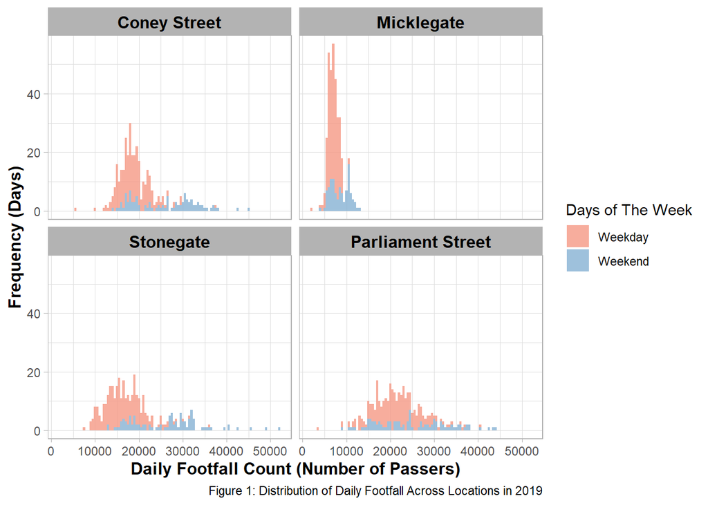

```r
# Add the Days_of_The_Week column to indicate data recorded at weekends and set LocationName and Days_of_The_Week in a specific order, leading to the plots of Coney Street and Stonegate being on the same column, a display fitted to the following analysis.

york_footfall.2019 <- york_footfall.2019 %>%
  mutate(
    LocationName = factor(LocationName, levels = c("Coney Street", "Micklegate", "Stonegate", "Parliament Street")),
    Days_of_The_Week = factor(ifelse(WeekDay %in% c("Saturday", "Sunday"), "Weekend", "Weekday"),
                              levels = c("Weekday", "Weekend")))

# Plot the distribution plot

york.plot <- york_footfall.2019 %>%
  ggplot(york_footfall.2019, mapping = aes(fill = Days_of_The_Week, x = TotalCount)) +
  geom_histogram(alpha = 0.8, binwidth = 500, position = "stack") +
  facet_wrap(~ LocationName, ncol=2, nrow = 2) +
  labs(
    caption = "Figure 1: Distribution of Daily Footfall Across Locations in 2019",
    x = "Daily Footfall Count (Number of Passers)",
    y = "Frequency (Days)"
  ) +
  # Assign specific colours to the difference of weekdays and weekends
  scale_fill_manual(values = c("Weekday" = "#F59885", "Weekend" = "#86B1D3"), name = "Days of The Week") +
  # Change the theme of plot into light
  theme_light() +
  # Change the style and size of x and y axis
  theme(
    axis.title.x = element_text(size = 12, face = "bold"),
    axis.title.y = element_text(size = 12, face = "bold"),
    strip.text = element_text(size = 12, color = "black", face = "bold")
  )

york.plot
```

The plot shows that the daily footfall in Micklegate ranged from 5,000 to 10,000, a lower volume than in other locations. According to the distribution plot (Figure 1), the other three locations have a more similar pattern of daily footfall, a more significant proportion of attracting 15,000 to 20,000 passers during the weekdays. In contrast, according to legends that show on the right side of the plot, they also perform a common phenomenon that happened in four locations: footfall at weekends is typically higher than on weekdays. Some days, there is an exceptionally high volume in Stonegate, which is valuable for finding the reason.

## 4. Perform a two-sided t-test to compare the footfall on Coney Street to Stonegate.

```r
# Subset data for Coney Street and Stonegate
all_days_data <- york_footfall.2019 %>%
  filter(LocationName %in% c("Coney Street", "Stonegate"))

# Main t-test (all available days)
t.test(TotalCount ~ LocationName, data = all_days_data)
```

```
##
##  Welch Two Sample t-test
##
## data:  TotalCount by LocationName
## t = 3.3611, df = 699.18, p-value = 0.0008186
## alternative hypothesis: true difference in means between group Coney Street and group Stonegate is not equal to 0
## 95 percent confidence interval:
##   670.9189 2555.7989
## sample estimates:
## mean in group Coney Street    mean in group Stonegate
##                   20817.45                   19204.09
```

```r
# Sensitivity check: exclude days with very high counts
# (cap chosen based on inspection of the histogram; used only for robustness check)
upper_cap <- 40000

all_days_no_extreme <- all_days_data %>%
  filter(TotalCount < upper_cap)

t.test(TotalCount ~ LocationName, data = all_days_no_extreme)
```

```
##
##  Welch Two Sample t-test
##
## data:  TotalCount by LocationName
## t = 4.3312, df = 706.17, p-value = 1.698e-05
## alternative hypothesis: true difference in means between group Coney Street and group Stonegate is not equal to 0
## 95 percent confidence interval:
##  1047.662 2785.005
## sample estimates:
## mean in group Coney Street    mean in group Stonegate
##                   20690.80                   18774.47
```

The average number of daily passers on Coney Street is 20,817, compared with 19,204 on Stonegate, a difference of 1,613 passers. This difference is statistically significant, $t(699.18) = 3.36$, $p = 0.0008$.

Figure 2 supports this result: the distribution for Coney Street is shifted to the right, and the mean footfall line lies clearly to the right of that for Stonegate.

To check whether the conclusion is driven by a small number of very high footfall values, a **sensitivity analysis** was conducted by excluding days with TotalCount ≥ 40,000. The t-test on this restricted sample remains significant and the difference in means is similar, indicating that the finding that Coney Street attracts higher daily footfall than Stonegate is robust to the treatment of these extreme values.

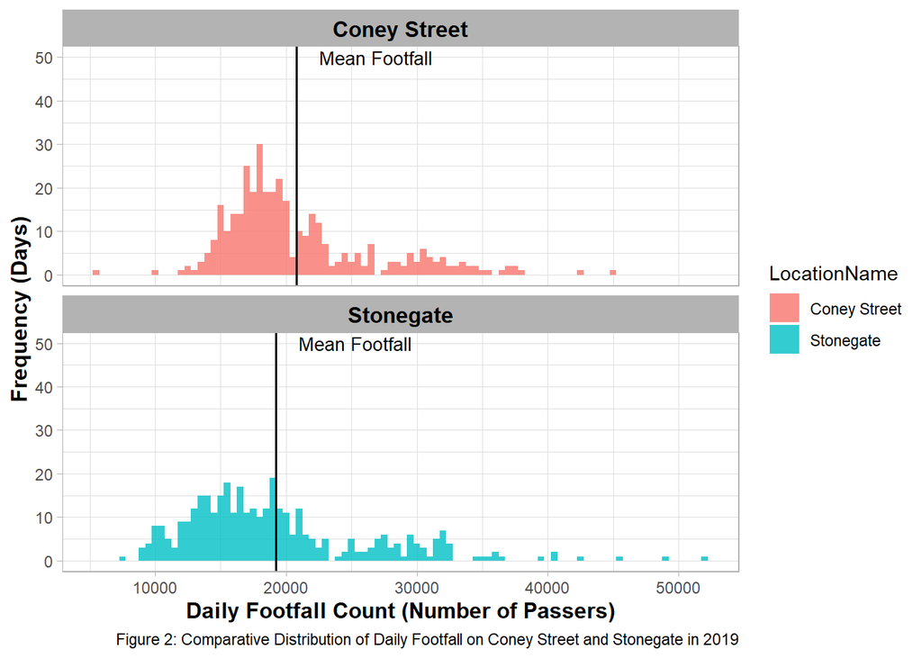

```r
# Prepare the mean footfall on Coney Street and Stonegate (all days)
mean_total_count.all.days <- all_days_data %>%
  group_by(LocationName) %>%
  summarise(mean_count = mean(TotalCount), .groups = "drop")

# Histogram for all days
plot1 <- all_days_data %>%
  ggplot(aes(x = TotalCount, fill = LocationName)) +
  geom_histogram(alpha = 0.8, binwidth = 500, position = "stack") +
  facet_wrap(~ LocationName, nrow = 2) +
  labs(
    caption = "Figure 2: Comparative Distribution of Daily Footfall on Coney Street and Stonegate in 2019",
    x = "Daily Footfall Count (Number of Passers)",
    y = "Frequency (Days)"
  ) +
  geom_vline(data = mean_total_count.all.days,
             aes(xintercept = mean_count), size = 0.6) +
  geom_text(data = mean_total_count.all.days,
            aes(x = mean_count, y = 50, label = "Mean Footfall"),
            hjust = -0.2, size = 3.5) +
  theme_light() +
  theme(
    axis.title.x = element_text(size = 12, face = "bold"),
    axis.title.y = element_text(size = 12, face = "bold"),
    strip.text   = element_text(size = 12, colour = "black", face = "bold")
  )

plot1
```

## 5. Perform an additional two-sided t-test to compare the footfall on Coney Street to Stonegate only on weekends (i.e. Saturdays/Sundays).

```r
# Subset weekend data (Saturdays and Sundays only)
weekend_data <- york_footfall.2019 %>%
  filter(LocationName %in% c("Coney Street", "Stonegate"),
         WeekDay %in% c("Saturday", "Sunday"))

# Main weekend t-test
t.test(TotalCount ~ LocationName, data = weekend_data)
```

```
##
##  Welch Two Sample t-test
##
## data:  TotalCount by LocationName
## t = -0.29072, df = 203.88, p-value = 0.7716
## alternative hypothesis: true difference in means between group Coney Street and group Stonegate is not equal to 0
## 95 percent confidence interval:
##  -2362.601  1755.409
## sample estimates:
## mean in group Coney Street    mean in group Stonegate
##                   25863.37                   26166.96
```

```r
# Sensitivity check on weekends using the same upper cap
weekend_no_extreme <- weekend_data %>%
  filter(TotalCount < upper_cap)

t.test(TotalCount ~ LocationName, data = weekend_no_extreme)
```

```
##
##  Welch Two Sample t-test
##
## data:  TotalCount by LocationName
## t = 0.52608, df = 198, p-value = 0.5994
## alternative hypothesis: true difference in means between group Coney Street and group Stonegate is not equal to 0
## 95 percent confidence interval:
##  -1352.677  2336.976
## sample estimates:
## mean in group Coney Street    mean in group Stonegate
##                   25511.59                   25019.44
```

At weekends, the mean number of daily passers is 25,863 on Coney Street and 26,167 on Stonegate, a difference of 304 passers. The two-sided t-test shows that this difference is not statistically significant, $t(203.88) = −0.29$, $p = 0.772$.

This is consistent with Figure 3, where the weekend distributions of the two locations look broadly similar, with only a slight difference in their mean lines.

As with the all-days analysis, a sensitivity check was carried out by excluding days with TotalCount ≥ 40,000. After removing these extreme values, the mean weekend footfall is 25,512 on Coney Street and 25,019 on Stonegate, a difference of 493 passers. However, this difference remains non-significant, $t(198) = 0.53$, $p = 0.599$.

This confirms that the conclusion of no meaningful difference in average weekend footfall between the two streets is not sensitive to how these extreme days are treated.

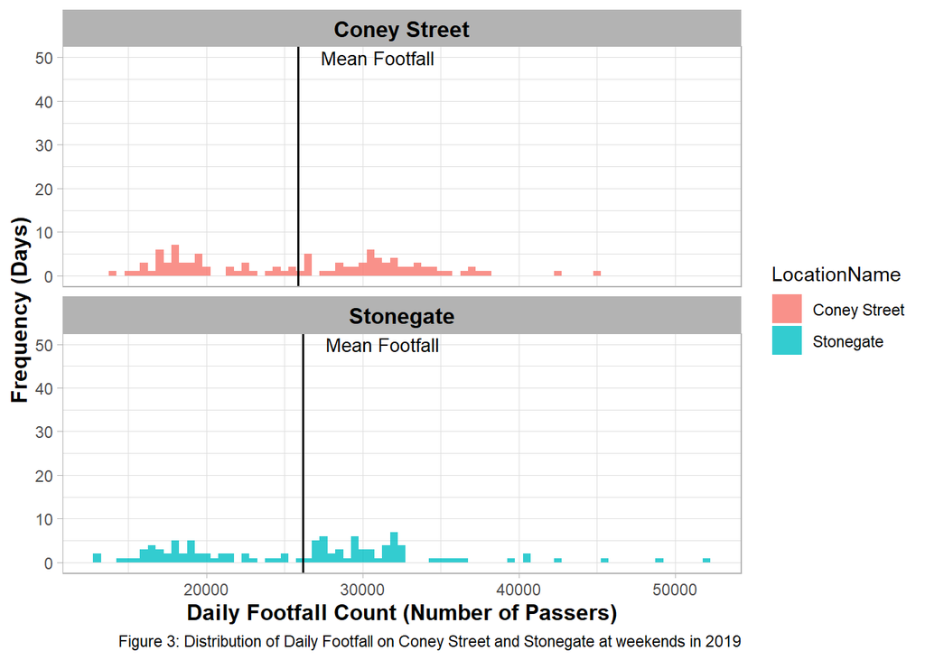

```r
# Prepare the mean weekend footfall
mean_total_count.weekends <- weekend_data %>%
  group_by(LocationName) %>%
  summarise(mean_count = mean(TotalCount), .groups = "drop")

# Histogram for weekends
plot2 <- weekend_data %>%
  ggplot(aes(x = TotalCount, fill = LocationName)) +
  geom_histogram(alpha = 0.8, binwidth = 500, position = "stack") +
  facet_wrap(~ LocationName, nrow = 2) +
  labs(
    caption = "Figure 3: Distribution of Daily Footfall on Coney Street and Stonegate at weekends in 2019",
    x = "Daily Footfall Count (Number of Passers)",
    y = "Frequency (Days)"
  ) +
  geom_vline(data = mean_total_count.weekends,
             aes(xintercept = mean_count), size = 0.6) +
  geom_text(data = mean_total_count.weekends,
            aes(x = mean_count, y = 50, label = "Mean Footfall"),
            hjust = -0.2, size = 3.5) +
  theme_light() +
  theme(
    axis.title.x = element_text(size = 12, face = "bold"),
    axis.title.y = element_text(size = 12, face = "bold"),
    strip.text   = element_text(size = 12, colour = "black", face = "bold")
  )

plot2
```

# Recommendation to The Promoter

Based on the findings above:

- **All days of the week** Coney Street records a significantly higher average daily footfall than Stonegate, and this result is robust to the exclusion of extreme high-footfall days.

  *Recommendation*: If the stall is to be placed every day, Coney Street is the preferred location for maximising exposure.
- **Weekends only (Saturdays/Sundays)** The difference in average weekend footfall between Coney Street and Stonegate is not statistically significant, and this conclusion does not change when extreme days are excluded. Stonegate occasionally shows very high counts, but these are infrequent; Coney Street offers a slightly more stable pattern.

  *Recommendation*: When operating only at weekends, either street is viable, but Coney Street is marginally preferred as a more consistent and lower-risk option.